# Decoherence in a Hadamard Quantum Random Walk on a Line

## Overview

This vignette demonstrates how to simulate and compare:

- a **noiseless** Hadamard quantum random walk (QRW),
- a **noisy** (decohering) Hadamard QRW simulated via **Monte Carlo quantum trajectories**, and
- a **classical** symmetric random walk (SRW) baseline.

The core unitary QRW step is

$$U = S(H \otimes I_p),$$

where $H$ is the Hadamard coin and $S$ is the conditional shift. In the noisy case, the state is updated via a Kraus channel on the coin, using Monte Carlo sampling of outcomes.

```r
library(tidyverse)
library(decoherentqrw)
```

## Quick start

We will simulate each model for the same number of steps `T`.

```r
T <- 20
```

### Noiseless Hadamard Walk

```r
T <- 60

noiseless <- sim_noiseless_qrw(T, "symmetric")

srw <- sim_srw(T)

pos <- pos_grid(T)
```

## Final Position Distribution

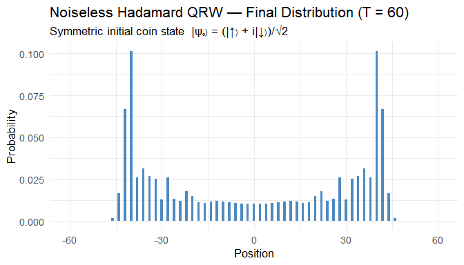

```r
tibble(

  position = pos,

  prob = noiseless$dists[T + 1, ]

) |>
  ggplot(aes(x = position, y = prob)) +

  geom_col(fill = "#2E75B6", width = 0.8, alpha = 0.85) +

  labs(
    title = paste0("Noiseless Hadamard QRW — Final Distribution (T = ", T, ")"),

    subtitle = "Symmetric initial coin state  |ψ₀⟩ = (|↑⟩ + i|↓⟩)/√2",

    x = "Position",

    y = "Probability"
  ) +
  theme_minimal(base_size = 13)
```

### Noisy Hadamard QRW (Monte Carlo trajectories)

For the noisy walk we choose:

- a decoherence channel (`"dephasing"` or `"depolarizing"`)
- strength `p in [0,1]`
- number of trajectories `N`

```r
N <- 200

channel <- "dephasing"

p <- 0.15

noisy <- sim_noisy_qrw(
  T = T, N = N,

  channel = channel,

  init_coin = "symmetric",

  p = p,

  seed = 1
)

str(noisy)
```

```
#> List of 4
#>  $ T    : num 60
#>  $ dists: num [1:61, 1:121] 0 0 0 0 0 0 0 0 0 0 ...
#>  $ means: num [1:61] 0 -0.02 0.01 -0.04 -0.06 ...
#>  $ vars : num [1:61] 0 1 2.02 3.01 4.71 ...
```

### Classical SRW baseline

```r
classical <- sim_srw(T = T)

str(classical)
```

```
#> List of 4
#>  $ T    : num 60
#>  $ dists: num [1:61, 1:121] 0 0 0 0 0 0 0 0 0 0 ...
#>  $ means: num [1:61] 0 0 0 0 0 0 0 0 0 0 ...
#>  $ vars : num [1:61] 0 1 2 3 4 5 6 7 8 9 ...
```

## Interpreting the outputs

### Final time distribution comparison

At time `T`, we can compare the three final distributions:

```r
set.seed(42)

T  <- 60

N <- 2000

noisy_deph <- sim_noisy_qrw(

  T = T,

  N = N,

  channel = "dephasing",

  init_coin = "symmetric",

  p = 0.1,

  seed = 42
)
```

An overlay plot of all three final distributions:

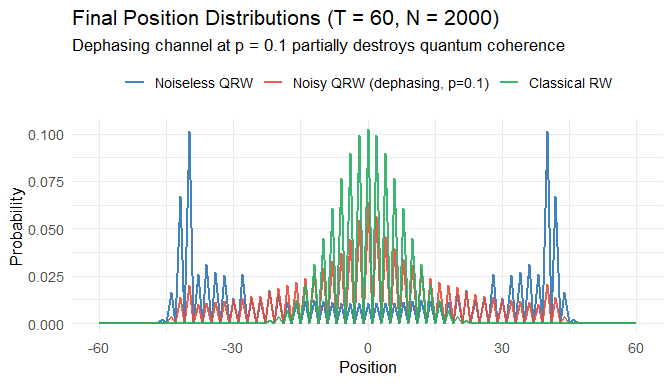

```r
dist_tbl <- build_dist(noisy_deph, noiseless, srw)

dist_tbl |>

  pivot_longer(c(noisy, noiseless, classical),
               names_to = "model", values_to = "prob") |>

  mutate(model = factor(model,

    levels = c("noiseless", "noisy", "classical"),

    labels = c("Noiseless QRW", "Noisy QRW (dephasing, p=0.1)", "Classical RW"))) |>

  ggplot(aes(x = pos, y = prob, colour = model)) +

  geom_line(linewidth = 0.9, alpha = 0.9) +

  scale_colour_manual(values = c("#2E75B6", "#E74C3C", "#27AE60")) +

  labs(
    title    = paste0("Final Position Distributions (T = ", T, ", N = ", N, ")"),
    subtitle = "Dephasing channel at p = 0.1 partially destroys quantum coherence",
    x        = "Position", y = "Probability", colour = NULL
  ) +

  theme_minimal(base_size = 13) +

  theme(legend.position = "top")
```

# Quantum to Classical Transition

We vary $p \in \{0, 0.05, 0.1, 0.3, 0.5, 1.0\}$ and examine how the position variance changes from ballistic ($\text{Var} \sim t^2$) to diffusive ($\text{Var} \sim t$) scaling.

```r
set.seed(99)

p_sweep  <- c(0, 0.05, 0.1, 0.3, 0.5, 1.0)

T  <- 50

N  <- 1500

nl <- sim_noiseless_qrw(T, "symmetric")

cl <- sim_srw(T)

noisy_list <- lapply(p_sweep, function(p) {

  sim_noisy_qrw(T, N, "dephasing", "symmetric", p, seed = 99)
})

names(noisy_list) <- as.character(p_sweep)
```

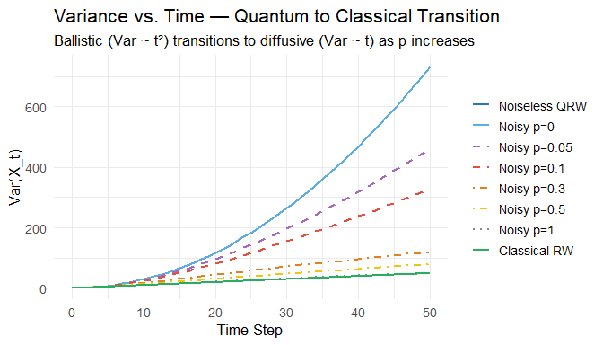

```r
var_rows <- lapply(p_sweep, function(p) {

  tibble(

    time  = 0:T,

    var   = noisy_list[[as.character(p)]]$vars,

    label = paste0("Noisy p=", p)
  )
})

var_tbl <- bind_rows(var_rows) |>

  bind_rows(

    tibble(time = 0:T, var = nl$vars,  label = "Noiseless QRW"),

    tibble(time = 0:T, var = cl$vars,  label = "Classical RW")
  ) |>

  mutate(label = factor(label, levels = c(

    "Noiseless QRW",

    paste0("Noisy p=", p_sweep),

    "Classical RW"
  )))

ggplot(var_tbl, aes(x = time, y = var, colour = label, linetype = label)) +

  geom_line(linewidth = 0.85) +

  scale_colour_manual(values = c(
    "Noiseless QRW" = "#2E75B6",
    "Noisy p=0"     = "#5DADE2",
    "Noisy p=0.05"  = "#A569BD",
    "Noisy p=0.1"   = "#E74C3C",
    "Noisy p=0.3"   = "#E67E22",
    "Noisy p=0.5"   = "#F1C40F",
    "Noisy p=1"     = "#7F8C8D",
    "Classical RW"  = "#27AE60"
  )) +

  scale_linetype_manual(values = c(
    "Noiseless QRW" = "solid",
    "Noisy p=0"     = "solid",
    "Noisy p=0.05"  = "dashed",
    "Noisy p=0.1"   = "dashed",
    "Noisy p=0.3"   = "dotdash",
    "Noisy p=0.5"   = "dotdash",
    "Noisy p=1"     = "dotted",
    "Classical RW"  = "solid"
  )) +

  labs(
    title    = "Variance vs. Time — Quantum to Classical Transition",

    subtitle = "Ballistic (Var ~ t²) transitions to diffusive (Var ~ t) as p increases",

    x        = "Time Step", y = "Var(X_t)",

    colour   = NULL, linetype = NULL
  ) +

  theme_minimal(base_size = 13) +

  theme(legend.position = "right")
```

# Dephasing vs. Depolarizing Channel Comparison

```r
set.seed(7)

p  <- 0.2

T  <- 60

N  <- 2000

noisy_dep  <- sim_noisy_qrw(T, N, "dephasing",    "symmetric", p, seed = 7)

noisy_depo <- sim_noisy_qrw(T, N, "depolarizing", "symmetric", p, seed = 7)

nl    <- sim_noiseless_qrw(T, "symmetric")

cl    <- sim_srw(T)
```

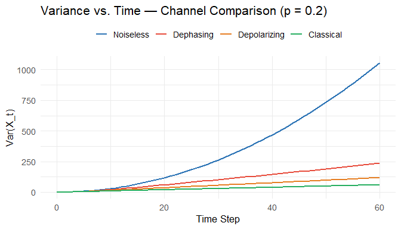

```r
tibble(

  time         = 0:T,

  Noiseless    = nl$vars,

  Dephasing    = noisy_dep$vars,

  Depolarizing = noisy_depo$vars,

  Classical    = cl$vars
) |>

  pivot_longer(-time, names_to = "model", values_to = "var") |>

  mutate(model = factor(model,
    levels = c("Noiseless", "Dephasing", "Depolarizing", "Classical"))) |>

  ggplot(aes(x = time, y = var, colour = model)) +

  geom_line(linewidth = 0.9) +

  scale_colour_manual(

    values = c("Noiseless" = "#2E75B6", "Dephasing" = "#E74C3C",

               "Depolarizing" = "#E67E22", "Classical" = "#27AE60")) +

  labs(

    title    = paste0("Variance vs. Time — Channel Comparison (p = ", p, ")"),

    x        = "Time Step", y = "Var(X_t)", colour = NULL
  ) +

  theme_minimal(base_size = 13) +

  theme(legend.position = "top")
```

# Summary table at time `T`

```r
T    <- 60

N    <- 3000

set.seed(123)

noisy_w    <- sim_noisy_qrw(T, N, "dephasing", "symmetric", 0.1, seed = 123)

noiseless_w   <- sim_noiseless_qrw(T, "symmetric")

classical_w   <- sim_srw(T)

summ <- build_summary_table(noisy_w, noiseless_w, classical_w)

knitr::kable(

  summ,

  digits  = 4,

  caption = paste0("Final-time summary (T = ", T, ", N = ", N,
                   ", dephasing p = 0.1, symmetric initial coin)"),
  col.names = c("Model", "Mean E[X_T]", "Variance Var(X_T)")
)
```

Final-time summary (T = 60, N = 3000, dephasing p = 0.1, symmetric initial coin)

| Model | Mean E[X_T] | Variance Var(X_T) |
| --- | --- | --- |
| noisy | 0.1089 | 420.1691 |
| noiseless | 0.0000 | 1054.8938 |
| classical | 0.0000 | 60.0000 |

## Reproducibility

For Monte Carlo runs, use the `seed` argument in `sim_noisy_qrw()` to make results reproducible.

```r
noisy2 <- sim_noisy_qrw(T = 10, N = 50, channel = "dephasing",
                        init_coin = "symmetric", p = 0.2, seed = 123)
tail(noisy2$vars, 1)
```

```
#> [1] 21.18369
```

# Comments

A.I usage description:

It was used to help with understanding and creating roxygen documentation and the vignette.

It was used to help with creation of some of the plots. The R Graph Gallery was also used to help with plots.

Some tests were created using A.I, however every test was manually confirmed. The majority of the tests were manually made.

None of the implementation was created by A.I, however once the all the implementations were done A.I was used to verify the validity of the implementations, which lead to discovery some minor bugs such as off by one errors and rounding errors.

# References

Holtz, Yan. n.d. “The r Graph Gallery: Help and Inspiration for R Charts.” https://r-graph-gallery.com.

Kassambara, Alboukadel. 2018. “Rename Data Frame Columns in r.” https://www.datanovia.com/en/lessons/rename-data-frame-columns-in-r/.

R Core Team. 2026. *R: Complex Numbers and Basic Functionality*. R Foundation for Statistical Computing. https://stat.ethz.ch/R-manual/R-devel/library/base/html/complex.html.

Voss, Jochen. 2013. *An Introduction to Statistical Computing: A Simulation-Based Approach*. John Wiley & Sons.

W3Schools. n.d. “R Data Frames.” https://www.w3schools.com/r/r_data_frames.asp.

Wickham, Hadley, and Jennifer Bryan. 2023. “Vignettes.” In *R Packages: Organize, Test, Document, and Share Your Code*, 2nd ed. O’Reilly Media. https://r-pkgs.org/vignettes.html.